# Midpoint Deliverable

## Intro Paragraph

Safety issues have always been in the spotlight, in the United States as strict gun regulations do not exist. And with the non-stop UW Alert messages reporting crimes, such as robberies and gun fires, safety has become one of the UW students’ major concerns nowadays. Therefore, as a team, we decided to tie this project to our daily lives and analyze the pattern of crimes around our community - *Seattle*.

We will be using [SPD Crime Data](https://data.seattle.gov/Public-Safety/SPD-Crime-Data-2008-Present/tazs-3rd5) as it provides crime data using the standardized crime classifications. However, due to the extreme size of the dataset, we’ve decided to take a portion of the orginal dataset and examine those data. In our analysis, we will be using columns such as offense start time, latitude & longitude, offense type, call-in resolution, etc., to help us answer these following questions:

- What areas have the highest density of crime?
- What types of crime? And in what areas?
- What is the time of year or day for the offense, length of offense, report date?
- What is the relationship between call-ins and arrests (i.e. resolution of call-ins)?

#### Addtional Sources for the Future

- [King County Sheriff’s Office - Incident Dataset](https://data.kingcounty.gov/Law-Enforcement-Safety/King-County-Sheriff-s-Office-Incident-Dataset/rzfs-wyvy): This dataset contains instances of crime reported by King Country Sherrif office and another policing agency, e.g. SPD.
- [911 Seattle Call Data](https://data.seattle.gov/Public-Safety/Call-Data/33kz-ixgy): 911 call data is from the Data Analytics Platform (DAP) and is logged with the Seattle Police Department (SPD) Communications Center. It contains calls of police officers and observations of the field from within the community and is updated(upload) daily before a full refresh twice a year. Although the dataset is quite huge with 4.34 Million rows of data, we acknowledge our constraint as this dataset only includes records with police responses to the 911 call.

## Summary Paragraph

The Seattle SPD data contains 17 columns with 832692 rows of data. It is a very large dataset that contains almost every police incident starting in 2008. It breaks down Offenses into 32 parent types, with a total of 59 unique offense types. Some interesting stats which we figured out from this dataset include safest/worst neighborhoods and common offense types. We found that the overall average number of crimes per neighborhood was 14113.

### Safest Neighborhood

1. COMMERCIAL HARBOR ISLAND
2. COMMERCIAL DUWAMISH
3. PIGEON POINT

### Worst Neighborhood

1. DOWNTOWN COMMERCIAL
2. CAPITOL HILL
3. NORTHGATE

Throughout the city we found a trend of the most common crimes, and surprising list of uncommon crimes as well.

### Most Common Crimes

1. Theft From Motor Vehicle
2. Burglary/Breaking & Entering
3. Destruction/Damage/Vandalism of Property

### Least Common Crimes

1. Gambling Equipment Violation
2. Human Trafficking, Involuntary Servitude
3. Operating/Promoting/Assisting Gambling

## Average Delay in Report Time

Both tables below are ordered by the their report delay time from the most the least delay.

### By Neighborhood

This table groups the SPD Crime Data by neighborhoods (MCPP) and displays the average delay between crime occurrence to report filed in days (from 2008 - present). The rows are ordered by descending report delay time. Total crime occurrences were included to give perspective on the frequency of crimes in a given neighborhood. Interestingly, the range in the neighborhood report delay time is not nearly as large as the offense delay time. This suggests that there are a variety of crimes in different areas; however, certain areas experience specific types of crime more than others (i.e. the range in delay time still exists–which vary with offense type).

| MCPP | occurrences | report_delay |
| --- | --- | --- |
| UNKNOWN | 6778 | 64.94 days |
| COMMERCIAL DUWAMISH | 511 | 21.07 days |
| SOUTH BEACON HILL | 3899 | 19.21 days |
| RAINIER VIEW | 8611 | 17.69 days |
| MORGAN | 7279 | 16.53 days |
| SANDPOINT | 17325 | 16.43 days |
| NORTH ADMIRAL | 8095 | 16.03 days |
| ALKI | 4209 | 15.32 days |
| HIGH POINT | 6911 | 14.63 days |
| MAGNOLIA | 12682 | 13.97 days |
| LAKECITY | 23072 | 13.96 days |
| SOUTH PARK | 7303 | 13.77 days |
| CENTRAL AREA/SQUIRE PARK | 21159 | 13.30 days |
| MADRONA/LESCHI | 10712 | 13.30 days |
| PIGEON POINT | 1002 | 13.28 days |
| COLUMBIA CITY | 5497 | 12.11 days |
| PHINNEY RIDGE | 6891 | 11.98 days |
| CLAREMONT/RAINIER VISTA | 4558 | 11.77 days |
| BITTERLAKE | 16557 | 11.71 days |
| HIGHLAND PARK | 9639 | 11.68 days |
| QUEEN ANNE | 41291 | 11.67 days |
| MID BEACON HILL | 9471 | 11.55 days |
| ROXHILL/WESTWOOD/ARBOR HEIGHTS | 13023 | 11.52 days |
| NORTH DELRIDGE | 6307 | 11.36 days |
| LAKEWOOD/SEWARD PARK | 4734 | 11.08 days |
| MADISON PARK | 2760 | 10.97 days |
| EASTLAKE - WEST | 5080 | 10.91 days |
| BALLARD NORTH | 17557 | 10.71 days |
| ALASKA JUNCTION | 11261 | 10.67 days |
| SOUTH DELRIDGE | 3360 | 10.67 days |
| GEORGETOWN | 9966 | 10.64 days |
| JUDKINS PARK/NORTH BEACON HILL | 6834 | 10.57 days |
| ROOSEVELT/RAVENNA | 28733 | 10.39 days |
| MILLER PARK | 5357 | 10.38 days |
| WALLINGFORD | 14847 | 10.23 days |
| FAUNTLEROY SW | 3626 | 10.22 days |
| COMMERCIAL HARBOR ISLAND | 284 | 10.16 days |
| FIRST HILL | 24736 | 10.10 days |
| BALLARD SOUTH | 25047 | 9.80 days |
| GREENWOOD | 18748 | 9.62 days |
| GENESEE | 2457 | 9.44 days |
| MONTLAKE/PORTAGE BAY | 5372 | 9.36 days |
| RAINIER BEACH | 9585 | 9.35 days |
| HILLMAN CITY | 4310 | 9.08 days |
| CAPITOL HILL | 50779 | 9.01 days |
| SLU/CASCADE | 36614 | 8.93 days |
| NORTH BEACON HILL | 14521 | 8.89 days |
| FREMONT | 15343 | 8.62 days |
| BRIGHTON/DUNLAP | 12407 | 8.58 days |
| NEW HOLLY | 5282 | 8.55 days |
| NORTHGATE | 47442 | 8.19 days |
| EASTLAKE - EAST | 1256 | 8.17 days |
| MOUNT BAKER | 11083 | 7.29 days |
| BELLTOWN | 23394 | 7.25 days |
| UNIVERSITY | 32607 | 6.91 days |
| DOWNTOWN COMMERCIAL | 72951 | 6.32 days |
| PIONEER SQUARE | 14982 | 5.94 days |
| SODO | 14033 | 5.91 days |
| CHINATOWN/INTERNATIONAL DISTRICT | 22562 | 4.47 days |

### By Offense

This table groups the SPD Crime Data by crime type (Offense) and displays the average delay between crime occurrence to report filed in days (from 2008 - present).This unveils the correlation between crime types (i.e. assault, etc.) & how long it takes people to submit reports. Total crime occurrences were included to give perspective on the frequency of a specific crime. The rows are ordered by descending report delay time. Out of the top 8 longest delay times, 6 of them were crimes involving sex. Understandably, this may occur because the victim and/or those knowing of the offense may need time to process/collect/feel safe enough to report the event. For instance, while incest only had 42 occurrences since 2008, the average report delay time was nearly 3 years.

| Offense | occurrences | report_delay |
| --- | --- | --- |
| Incest | 42 | 1023.56 days |
| Statutory Rape | 123 | 304.34 days |
| Sodomy | 505 | 276.62 days |
| Impersonation | 12459 | 161.31 days |
| Embezzlement | 1839 | 140.13 days |
| Rape | 1899 | 133.85 days |
| Fondling | 2508 | 128.99 days |
| Sexual Assault With An Object | 168 | 126.23 days |
| Identity Theft | 5001 | 80.57 days |
| Family Offenses, Nonviolent | 10154 | 47.19 days |
| Bad Checks | 6595 | 44.00 days |
| Pornography/Obscene Material | 261 | 39.60 days |
| Welfare Fraud | 54 | 38.14 days |
| False Pretenses/Swindle/Confidence Game | 9887 | 34.61 days |
| Counterfeiting/Forgery | 4485 | 27.32 days |
| Wire Fraud | 1867 | 25.87 days |
| Assisting or Promoting Prostitution | 276 | 25.80 days |
| Hacking/Computer Invasion | 91 | 22.59 days |
| Credit Card/Automated Teller Machine Fraud | 17330 | 21.81 days |
| Human Trafficking, Involuntary Servitude | 1 | 20.71 days |
| Extortion/Blackmail | 566 | 14.77 days |
| Human Trafficking, Commercial Sex Acts | 20 | 12.89 days |
| Theft From Building | 23947 | 11.82 days |
| All Other Larceny | 70246 | 11.45 days |
| Theft of Motor Vehicle Parts or Accessories | 18802 | 9.55 days |
| Intimidation | 26926 | 7.51 days |
| Kidnapping/Abduction | 793 | 7.20 days |
| Pocket-picking | 2772 | 5.92 days |
| Burglary/Breaking & Entering | 89766 | 5.75 days |
| Murder & Nonnegligent Manslaughter | 295 | 4.50 days |
| Aggravated Assault | 25777 | 4.28 days |
| Justifiable Homicide | 24 | 3.92 days |
| Prostitution | 3589 | 3.81 days |
| Motor Vehicle Theft | 49170 | 3.62 days |
| Purchasing Prostitution | 105 | 3.62 days |
| Stolen Property Offenses | 4495 | 3.59 days |
| Destruction/Damage/Vandalism of Property | 76013 | 3.45 days |
| Theft From Motor Vehicle | 142937 | 3.33 days |
| Theft From Coin-Operated Machine or Device | 338 | 3.14 days |
| Driving Under the Influence | 15423 | 2.82 days |
| Peeping Tom | 168 | 2.71 days |
| Simple Assault | 65713 | 2.18 days |
| Curfew/Loitering/Vagrancy Violations | 865 | 2.05 days |
| Shoplifting | 53460 | 2.04 days |
| Arson | 1273 | 1.70 days |
| Robbery | 19380 | 1.60 days |
| Trespass of Real Property | 26858 | 1.11 days |
| Animal Cruelty | 26 | 0.92 days |
| Purse-snatching | 615 | 0.87 days |
| Drug/Narcotic Violations | 22538 | 0.83 days |
| Weapon Law Violations | 8066 | 0.71 days |
| Drug Equipment Violations | 3837 | 0.65 days |
| Liquor Law Violations | 2292 | 0.40 days |
| Bribery | 15 | 0.21 days |
| Gambling Equipment Violation | 1 | 0.19 days |
| Negligent Manslaughter | 8 | 0.18 days |
| Drunkenness | 5 | 0.09 days |
| Operating/Promoting/Assisting Gambling | 4 | 0.07 days |
| Betting/Wagering | 19 | 0.05 days |

For all crime types, the difference in time between crime occurrence and report averaged to 10.37 days. These two charts shed light on the lack of accuracy for immediate estimations of crime density (both by type and Seattle area). Specifically, crimes involving sexual offenses will most likely be under-reported & even if they are, potentially months or years after the offense takes place–making a fair prosecution difficult.

## Most Popular Criminal Type

For this chart, we are trying to answer the question what crime type is the most popular. We decided to use a bar chart because it is the clearest way to display comparison between counts of data. It displays the type on the x axis and the count on the y axis. Therefore, we can easily trace each intersection and know that “Larceny-Theft” is the most popular crime in the Seattle area. The second most popular crime was “Destruction/Damage/Vandalism of Property”

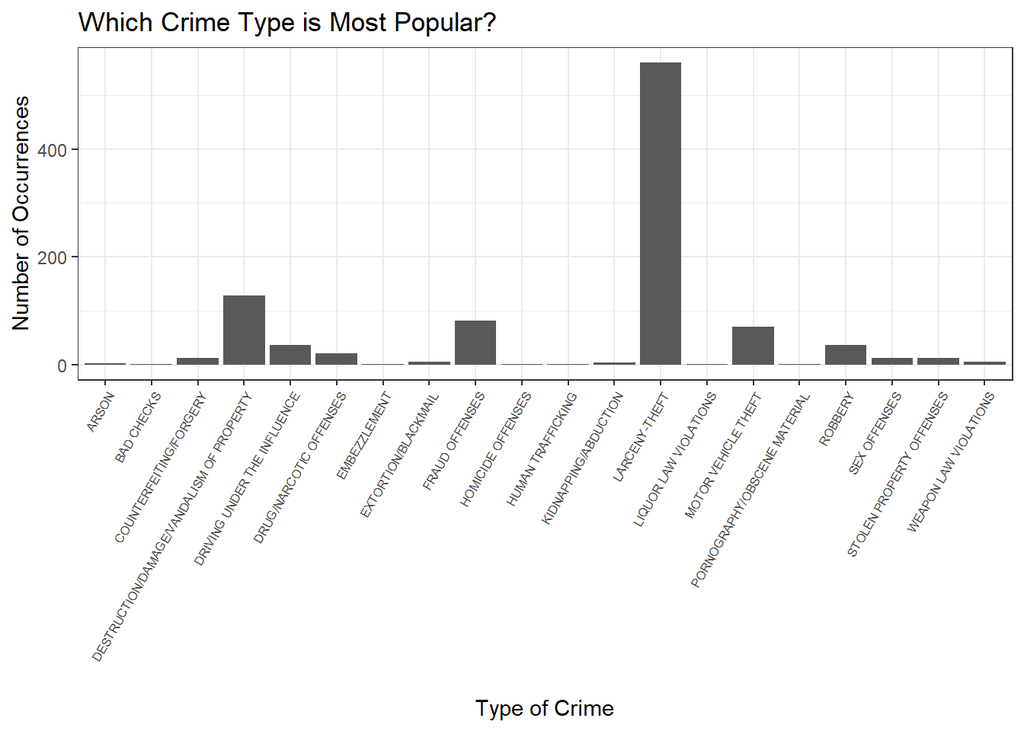

## Hour of Occurence

Criminal activity can theoretically occur at any time of day. An aspect that we wanted to explore was what times is/are most popular for crimes to happen. The chart below collects and compares the total number of offences across each hour of the day (in army time). This data was graphed using a scatterplot to not only show differences on the number of offences, but to also observe any potential trends. Aside from the extreme outlier at 0 hours (12:00 AM), it seems that as the day gets darker, or as it approaches the 20s, there is a slight increase in criminal offenses than times early in the morning/afternoon.

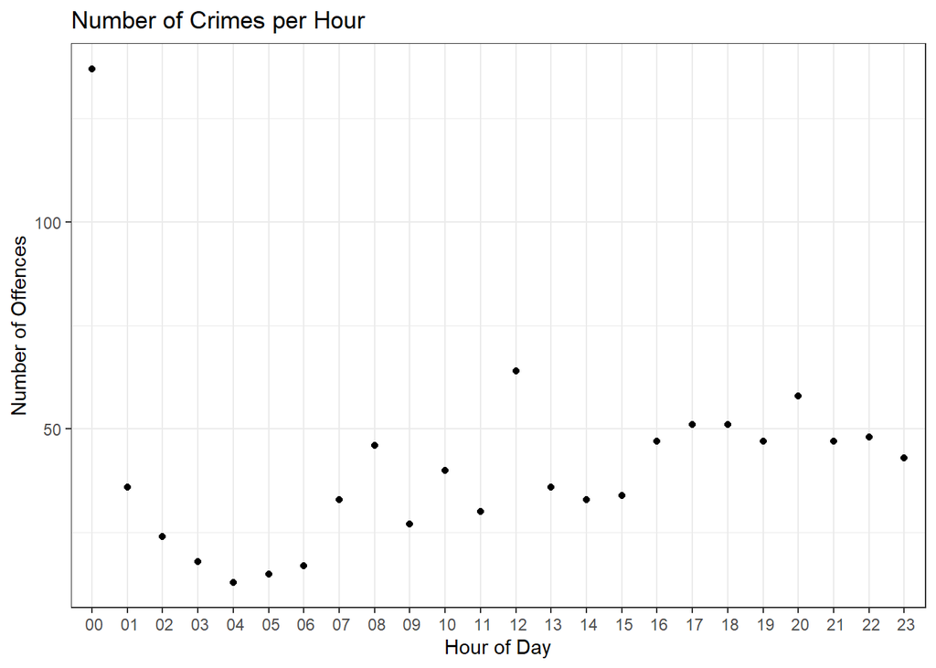

## Visualization of Seattle’s Criminal Activity

One of the most important aspect of the “911 Seattle Call Data” is that it contains longitudinal and latitudinal numbers. With this information, we decided to create an interactive map to show the relative location of each criminal activity. This method offers a unique perspective on not only the location of each crime call, but also which ‘offense’ was committed, which area of Seattle had the highest density of calls/crimes, and which ‘criminal type’ offense was done. Each point reveals information about the “Address”, “Crime Type” and “Offense”. Looking at the map, it appears that most of the offenses occurred within the N, E, and W precinct, with fewer occurences in precincts S and SW.

[interactive chart not shown]